# Price regression

```python
import pprint as pp
import numpy as np
import pandas as pd
import scipy
%matplotlib inline
import matplotlib.pyplot as plt
import seaborn as sns
from sklearn.linear_model import LinearRegression
from sklearn.model_selection import train_test_split
from sklearn.preprocessing import RobustScaler
```

### Initial dataset

```python
# Read data file
filename = 'used_ford_focuses.csv'
cars = pd.read_csv(filename)
```

```python
# Features and target variable
features = [
    'logMileage/year',
    'Age',
    'Horsepower',
    'Fuel_Gasoline',
    'Transmission type_Manual',
]
target = ['logPrice']
```

**Filters**

- No damaged cars, they tend to be outliers
- `Mileage km` > 1000, to filter out unused cars or false values
- Only cars before 2017, to filter out new cars
- No minivans (C-max variant, later became separate model)
- No extreme tuning versions (Focus RS) with `Horsepower` of 200-400
- No cars older than 20 years (obviously errors, as Focus was introduced in 1998...)
- Only cars with valid, domestic paperwork (others tend to be outliers)

```python
# HELPER FUNCTIONS

# Add new variables to dataframe
def create_variables(frame):
    frame['Age'] = 2017 - frame['Manufactured year']
    frame['logPrice'] = np.log10(frame['Price EUR'])
    frame['Mileage/year'] = frame['Mileage km'] / frame['Age']
    frame['logMileage/year'] = np.log10(frame['Mileage/year'])

    good_condition = ['Spared', 'Recent', 'Undamaged', 'Excellent', 'Normal']
    frame['Undamaged'] = frame['Condition'].isin(good_condition)

    cat_features = ['Form', 'Documents', 'Transmission type', 'Fuel']
    dummies = pd.get_dummies(frame[cat_features], drop_first = True, dummy_na=True)
    frame = pd.concat([frame, dummies], axis=1)
    return frame

# Filter out unwanted items
def filter_data(frame):
    return frame[(frame['Undamaged']) &
                 (frame['Mileage km'] > 1000) &
                 (frame['Manufactured year'] < 2017) &
                 (frame['Form'] != 'Minivan') &
                 (frame['Horsepower'] < 200) &
                 (frame['Age'] < 20) &
                 (frame['Documents_Valid, domestic'] == 1) &
                 (frame['Documents_nan'] == 0) &
                 (frame['Form_nan'] == 0) &
                 (frame['Fuel_nan'] == 0) &
                 (frame['Transmission type_nan'] == 0)][features + target].dropna()

def check_normality(predict, error):
    # Distribution of errors
    norm = np.random.normal(0, np.std(error), 100000)
    sns.distplot(error, hist=False)
    sns.distplot(norm, hist=False, kde_kws={'linewidth': 3, 'ls': 'dotted'})

    # Shapiro test for normality
    print(scipy.stats.shapiro(error))
```

### Getting the data ready

```python
# Get the dataset for modelling
cars = create_variables(cars)
data = filter_data(cars)
print(data.count())
```

```
logMileage/year             1764
Age                         1764
Horsepower                  1764
Fuel_Gasoline               1764
Transmission type_Manual    1764
logPrice                    1764
dtype: int64
```

`Age` and `logMileage/year` show somewhat higher correlation. That might cause multicollinearity.

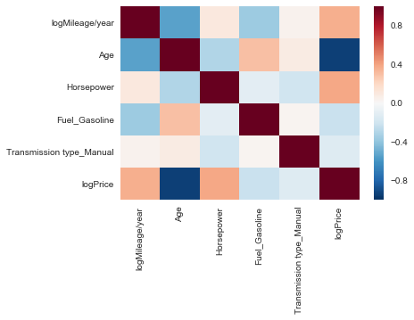

```python
sns.heatmap(data.corr())
```

### Modeling with scaled data

```python
# Split train and test sets
X_train, X_test, y_train, y_test = train_test_split(data[features],
                                                    data[target],
                                                    test_size=0.20,
                                                   random_state=543)
print('Train X: {}'.format(X_train.shape))
print('Train y: {}'.format(y_train.shape))
print('Test X: {}'.format(X_test.shape))
print('Test y: {}'.format(y_test.shape))
```

```
Train X: (1411, 5)
Train y: (1411, 1)
Test X: (353, 5)
Test y: (353, 1)
```

```python
# Scaler overrider class
class OverrideScaler:
    '''
    Plug-in replacement for scalers for experimenting without
    rewriting the whole code. Leaves data intact.
    '''
    def fit(self, data):
        return self

    def transform(self, data):
        return data

    def inverse_transform(self, data):
        return data
```

```python
# Scaling data
scalerX = OverrideScaler().fit(X_train)
scalerY = OverrideScaler().fit(y_train)

# Linear classifier and fitting model
clf = LinearRegression()
clf.fit(scalerX.transform(X_train), scalerY.transform(y_train))

# Print model
print('Intercept: {}'.format(clf.intercept_))
print('Coefficients: {}'.format(clf.coef_))
print('r2 on train set: {}'.format(clf.score(scalerX.transform(X_train), scalerY.transform(y_train))))
print('r2 on test set: {}'.format(clf.score(scalerX.transform(X_test), scalerY.transform(y_test))))
```

```
Intercept: [ 5.01491764]
Coefficients: [[-0.22134832 -0.05955043  0.00166677  0.01463949 -0.02766354]]
r2 on train set: 0.923347200975166
r2 on test set: 0.9278383960027059
```

The resiudal distribution on the test set is clearly not normal. AFAIK that is not necessary a dealbreaker, but nevertheless in theory this should be normal. Is the model biased? Maybe that's where multicollinearity kicks in?

```
(0.9803362488746643, 9.536957077216357e-05)
```

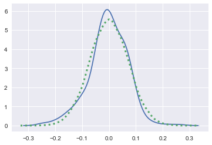

```python
# Calculate errors on test set
predict = clf.predict(scalerX.transform(X_test))
error = scalerY.transform(y_test) - predict

check_normality(predict, error)
```

## New ('wild') data

```python
# Read new data
new_file = 'used_ford_focuses_new_round.csv'
new_cars = pd.read_csv(new_file)
```

```python
# Filter data
new_cars = create_variables(new_cars)
new_data = filter_data(new_cars)
print(new_data.count())
```

```
logMileage/year             917
Age                         917
Horsepower                  917
Fuel_Gasoline               917
Transmission type_Manual    917
logPrice                    917
dtype: int64
```

```
r2 on new data: 0.9255053176262799
(0.9560282826423645, 6.009916342357587e-16)
```

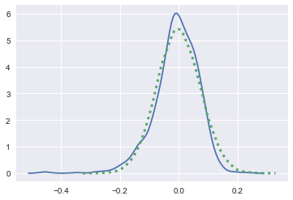

```python
# Split features and target variable
X_new =  new_data[features]
y_new = new_data[target]

# Score with scaled variables
print('r2 on new data: {}'.format(clf.score(scalerX.transform(X_new), scalerY.transform(y_new))))

# Calculate errors on test set
predict = clf.predict(scalerX.transform(X_new))
error = scalerY.transform(y_new) - predict

check_normality(predict, error)
```

The residuals look even uglier. The model is far from perfect.

### Quick check

```python
sample = np.array([
        [np.log10(10000), 3, 116.0, 0, 0],
        [np.log10(12000), 3, 116.0, 0, 0],
        [np.log10(12000), 4, 116.0, 0, 0],
        [np.log10(12000), 4, 126.0, 0, 0],
        [np.log10(12000), 4, 126.0, 1, 0],
        [np.log10(12000), 4, 126.0, 1, 1],
                 ])
predict = 10 ** (scalerY.inverse_transform(clf.predict(scalerX.transform(sample))))

print('20% increase in mileage/year: {}% change in price'.format(np.round((predict[1][0] / predict[0][0] - 1) * 100, 1)))
print('1 year increase in age: {}% change in price'.format(np.round((predict[2][0] / predict[1][0] - 1) * 100, 1)))
print('10 HP increase in power: {}% change in price'.format(np.round((predict[3][0] / predict[2][0] - 1) * 100, 1)))
print('Fuel == Gasoline: {}% change in price'.format(np.round((predict[4][0] / predict[3][0] - 1) * 100, 1)))
print('Transmission == Manual: {}% change in price'.format(np.round((predict[5][0] / predict[4][0] - 1) * 100, 1)))
```

```
20% increase in mileage/year: -4.0% change in price
1 year increase in age: -12.8% change in price
10 HP increase in power: 3.9% change in price
Fuel == Gasoline: 3.4% change in price
Transmission == Manual: -6.2% change in price
```

Adding predicted and inverse log-transformed price to the dataframe for easier plotting.

```python
new_data['Predicted_price'] = 10 ** scalerY.inverse_transform(clf.predict(scalerX.transform(X_new)))
new_data['Price'] = 10 ** new_data['logPrice']
```

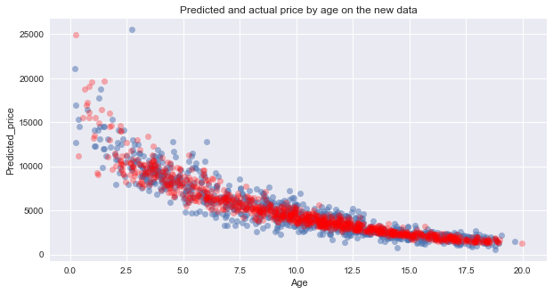

```python
fig, ax = plt.subplots(figsize=(10,5))
plt.title('Predicted and actual price by age on the new data')
sns.regplot(new_data['Age'], new_data['Price'], fit_reg=False, x_jitter=1, scatter_kws={'alpha': 0.5})
sns.regplot(new_data['Age'], new_data['Predicted_price'], fit_reg=False, x_jitter=1, scatter_kws={'alpha': 0.3, 'color': 'red'})
```

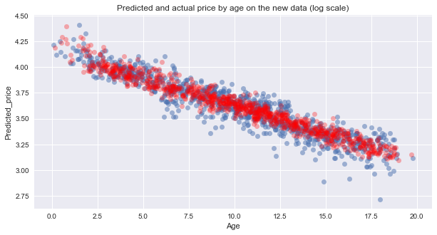

```python
fig, ax = plt.subplots(figsize=(10,5))
plt.title('Predicted and actual price by age on the new data (log scale)')
sns.regplot(new_data['Age'], new_data['logPrice'], fit_reg=False, x_jitter=1, scatter_kws={'alpha': 0.5})
sns.regplot(new_data['Age'], np.log10(new_data['Predicted_price']), fit_reg=False, x_jitter=1, scatter_kws={'alpha': 0.3, 'color': 'red'})
```

## Merging the datasets

```python
total_cars = pd.concat([cars, new_cars])
total_data = filter_data(total_cars)
```

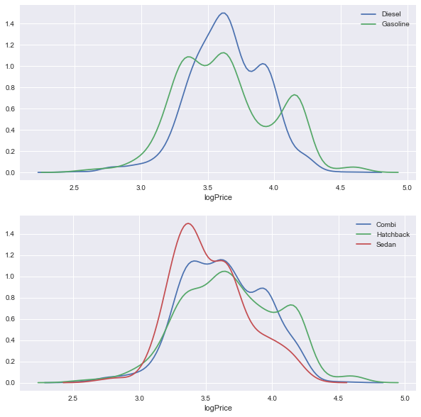

```python
fig, (ax1, ax2) = plt.subplots(2,1, figsize=(10,10))
for fuel in ['Diesel', 'Gasoline']:
    sns.distplot(total_cars[total_cars['Fuel'] == fuel]['logPrice'], label=fuel, hist=False, ax=ax1)
for form in ['Combi', 'Hatchback', 'Sedan']:
    sns.distplot(total_cars[total_cars['Form'] == form]['logPrice'], label=form, hist=False, ax=ax2)
```

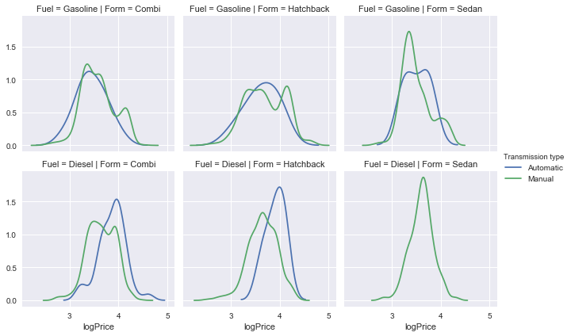

```python
forms = ['Combi', 'Hatchback', 'Sedan']
fuels = ['Diesel', 'Gasoline']
d = total_cars[(total_cars['Fuel'].isin(fuels)) & (total_cars['Form'].isin(forms))]
grid = sns.FacetGrid(data=d, hue='Transmission type', col='Form', row='Fuel', legend_out='True')
grid.map(sns.distplot, 'logPrice', hist=False).add_legend()
```